# Consensus OPLS for Multi-Block Data Fusion

Celine Bougel, Julien Boccard, Florence Mehl, Marie Tremblay-Franco, Mark Ibberson, Van Du T. Tran

February 27, 2025

# 1 The Consensus OPLS method

Omics approaches have proven their value to provide a broad monitoring of biological systems. However, despite the wealth of data generated by modern analytical platforms, the analysis of a single dataset is still limited and insufficient to reveal the full biochemical complexity of biological samples. The fusion of information from several data sources constitutes therefore a relevant approach to assess biochemical events more comprehensively. However, inherent problems encountered when analyzing single tables are amplified with the generation of multiblock datasets and finding the relationships between data layers of increasing complexity constitutes a challenging task. For that purpose, a versatile methodology is proposed by combining the strengths of established data analysis strategies, i.e. multiblock approaches and the OPLS-DA framework to offer an efficient tool for the fusion of Omics data obtained from multiple sources (Boccard Julien and Rutledge 2013).

The method, already available in MATLAB (available at [Gitlab repository](https://gitlab.unige.ch/Julien.Boccard/consensusopls)), has been translated into an R package (available at [GitHub repository](https://github.com/sib-swiss/consensusOPLS)) that includes quality metrics for optimal model selection, such as the R-squared (R²) coefficient, the Stone-Geisser Q² coefficient, the discriminant Q² index (DQ²) (Westerhuis et al. 2008), the permutation **diagnostics statistics** (Szymańska et al. 2012), as well as many graphical outputs (scores plot, block contributions, individual loadings, permutation results, etc.). It has been enhanced with additional functionalities such as the computation of the Variable Importance in Projection **(VIP) values** (Wold, Sjöström, and Eriksson 2001). Moreover, the new implementation now offers the possibility of using different kernels, i.e. linear (previously the only option was a kernel-based reformulations of the **NIPALS** algorithm (Lindgren, Geladi, and Wold 1993)), polynomial, or Gaussian, which greatly enhances the versatility of the method and extends its scope to a wide range of applications. The package also includes a function to **predict new samples** using an already computed model.

A demonstration case study available from a public repository of the National Cancer Institute, namely the NCI-60 data set, was used to illustrate the method’s potential for omics data fusion. A subset of NCI-60 data (transcriptomics, proteomics and metabolomics) involving experimental data from 14 cancer cell lines from two tissue origins, i.e. colon and ovary, was used (Shoemaker 2006). Results from the consensusOPLS R package and Matlab on this dataset were strictly identical (tolerance of 10e-06).

The combination of these data sources was excepted to provide a global profiling of the cell lines in an integrative systems biology perspective. The Consensus OPLS-DA strategy was applied for the differential analysis of the two selected tumor origins and the simultaneous analysis of the three blocks of data.

# 2 R environment preparation

```r
#install.packages("knitr")
library(knitr)
opts_chunk$set(echo = TRUE)

# To ensure reproducibility
set.seed(12)
```

Before any action, it is necessary to verify that the needed packages were installed (the code chunks are not shown, click on `Show` to open them). The code below has been designed to have as few dependencies as possible on R packages, except for the stable packages.

```r
pkgs <- c("ggplot2", "ggrepel", "DT", "psych", "ConsensusOPLS")
sapply(pkgs, function(x) {
  if (!requireNamespace(x, quietly = TRUE)) {
    install.packages(x)
  }
})
if (!require("BiocManager", quietly = TRUE))
  install.packages("BiocManager")
if (!requireNamespace("ComplexHeatmap", quietly = TRUE)) {
  BiocManager::install("ComplexHeatmap")
}
```

```r
library(ggplot2)        # to make beautiful graphs
library(ggrepel)        # to annotate ggplot2 graph
library(DT)             # to make interactive data tables
library(psych)          # to make specific quantitative summaries
library(ComplexHeatmap) # to make heatmap with density plot
library(ConsensusOPLS)  # to load ConsensusOPLS
```

Then we create a uniform theme (`theme_graphs`) that will be used for all graphic outputs.

```r
require(ggplot2)
theme_graphs <- theme_bw() + theme(strip.text = element_text(size=14),
                                   axis.title = element_text(size=16),
                                   axis.text = element_text(size=14),
                                   plot.title = element_text(size=16),
                                   legend.title = element_text(size=14))
```

# 3 Data preprocessing

As mentioned earlier, the demonstration dataset proposed in Matlab was used for the package.

```r
data(demo_3_Omics, package = "ConsensusOPLS")
```

This will load an data object of type list with 5 matrices MetaboData, MicroData, ObsNames, ProteoData, Y.

In other words, this list contains three data blocks, a list of observation names (samples), and the binary response matrix Y. Since the `ConsensusOPLS` method performs **horizontal integration**, with **kernel-based data fusion** (J. Boccard and Rudaz 2014), all data blocks should have exactly the same samples (rows). The block dimension can be checked with the following command:

```r
# Check dimension
BlockNames <- c("MetaboData", "MicroData", "ProteoData")
nbrBlocs <- length(BlockNames)
dims <- lapply(X=demo_3_Omics[BlockNames], FUN=dim)
names(dims) <- BlockNames
dims
```

```
## $MetaboData
## [1]  14 147
##
## $MicroData
## [1]  14 200
##
## $ProteoData
## [1] 14 99
```

```r
# Remove unuseful object for the next steps
rm(dims)
```

Now that the number of lines is identical, we need to check that they are the same subjects and in the same order for the different blocks.

```r
# Check rows names in any order
row_names <- lapply(X=demo_3_Omics[BlockNames], FUN=rownames)
rns <- do.call(cbind, row_names)
rns.unique <- apply(rns, 1, function(x) length(unique(x)))
if (max(rns.unique) > 1) {
  stop("Rows names are not identical between blocks.")
}

# Check order of samples
check_row_names <- all(sapply(X=row_names, FUN=identical, y = row_names[[1]]))
if (!check_row_names && max(rns.unique) == 1) {
  print("Rows names are not in the same order for all blocks.")
}

# Remove unuseful object for the next steps
rm(row_names, rns, rns.unique, check_row_names)
```

The identical order of samples in the three omics blocks should be ensured.

The list of the data blocks `demo_3_Omics[BlockNames]` and the response `demo_3_Omics$Y` are required as input to the ConsensusOPLS analysis.

# 4 Data visualization

## 4.1 Summary by Y groups

Before performing the multiblock analysis, we might investigate the nature of variables in each omics block w.r.t the response. The interactive tables are produced here below, so that the variables can be sorted in ascending or descending order. A variable of interest can also be looked up.

```r
require(psych)
require(DT)
describe_data_by_Y <- function(data, group) {
  bloc_by_Y <- describeBy(x = data, group = group,
                          mat = TRUE)[, c("group1", "n", "mean", "sd",
                                          "median", "min", "max", "range",
                                          "se")]
  bloc_by_Y[3:ncol(bloc_by_Y)] <- round(bloc_by_Y[3:ncol(bloc_by_Y)],
                                        digits = 2)
  return (datatable(bloc_by_Y))
}
```

For metabolomic data,

```r
describe_data_by_Y(data = demo_3_Omics[[BlockNames[1]]],
                   group = demo_3_Omics$ObsNames[,1])
```

|  | group1 | n | mean | sd | median | min | max | range | se |
| --- | --- | --- | --- | --- | --- | --- | --- | --- | --- |
| MT157081 | Colon | 7 | 0.96 | 0.78 | 0.9 | 0.21 | 2.18 | 1.97 | 0.3 |
| MT157082 | Ovarian | 7 | 0.36 | 0.23 | 0.21 | 0.21 | 0.83 | 0.61 | 0.09 |
| MT157091 | Colon | 7 | 0.55 | 0.51 | 0.37 | 0.07 | 1.24 | 1.17 | 0.19 |
| MT157092 | Ovarian | 7 | 0.49 | 0.3 | 0.59 | 0.07 | 0.87 | 0.8 | 0.12 |
| MT157101 | Colon | 7 | 1.14 | 0.17 | 1.13 | 0.94 | 1.45 | 0.52 | 0.06 |
| MT157102 | Ovarian | 7 | 1.24 | 0.59 | 1.04 | 0.51 | 1.9 | 1.39 | 0.22 |
| MT157111 | Colon | 7 | 0.32 | 0 | 0.32 | 0.32 | 0.32 | 0 | 0 |
| MT157112 | Ovarian | 7 | 0.63 | 0.24 | 0.78 | 0.32 | 0.89 | 0.57 | 0.09 |
| MT157121 | Colon | 7 | 0.27 | 0.13 | 0.22 | 0.22 | 0.56 | 0.34 | 0.05 |
| MT157122 | Ovarian | 7 | 0.22 | 0 | 0.22 | 0.22 | 0.22 | 0 | 0 |

[output cut: 284 more lines]

For microarray data,

```r
describe_data_by_Y(data = demo_3_Omics[[BlockNames[2]]],
                   group = demo_3_Omics$ObsNames[,1])
```

|  | group1 | n | mean | sd | median | min | max | range | se |
| --- | --- | --- | --- | --- | --- | --- | --- | --- | --- |
| GC268551 | Colon | 7 | 126.68 | 24.63 | 119.64 | 90.78 | 167.74 | 76.97 | 9.31 |
| GC268552 | Ovarian | 7 | 77 | 18.81 | 77.14 | 45.08 | 101.57 | 56.48 | 7.11 |
| GC268561 | Colon | 7 | 97.55 | 13.47 | 100.06 | 76.18 | 115.2 | 39.02 | 5.09 |
| GC268562 | Ovarian | 7 | 133.41 | 30.46 | 148.73 | 84.15 | 165.11 | 80.96 | 11.51 |
| GC268571 | Colon | 7 | 214.04 | 28.55 | 202.53 | 182.71 | 265.38 | 82.67 | 10.79 |
| GC268572 | Ovarian | 7 | 210.3 | 36.76 | 209.1 | 151.64 | 265.44 | 113.81 | 13.89 |
| GC268581 | Colon | 7 | 189.09 | 35.69 | 188.28 | 149.41 | 248.53 | 99.12 | 13.49 |
| GC268582 | Ovarian | 7 | 184.76 | 104.24 | 171.59 | 79.33 | 340.28 | 260.95 | 39.4 |
| GC268591 | Colon | 7 | 14.15 | 4 | 16.44 | 7.71 | 17.97 | 10.27 | 1.51 |
| GC268592 | Ovarian | 7 | 20 | 14.55 | 11.98 | 8.56 | 48.83 | 40.27 | 5.5 |

[output cut: 390 more lines]

For proteomic data,

```r
describe_data_by_Y(data = demo_3_Omics[[BlockNames[3]]],
                   group = demo_3_Omics$ObsNames[,1])
```

|  | group1 | n | mean | sd | median | min | max | range | se |
| --- | --- | --- | --- | --- | --- | --- | --- | --- | --- |
| MT11261 | Colon | 7 | 3271.57 | 1037.5 | 2827 | 2243 | 4930 | 2687 | 392.14 |
| MT11262 | Ovarian | 7 | 822 | 478.52 | 758 | 278 | 1607 | 1329 | 180.86 |
| MT11271 | Colon | 7 | 84 | 185.75 | 7 | 0 | 503 | 503 | 70.21 |
| MT11272 | Ovarian | 7 | 473.43 | 580.09 | 283 | 5 | 1703 | 1698 | 219.25 |
| MT11281 | Colon | 7 | 105.43 | 31.09 | 108 | 59 | 159 | 100 | 11.75 |
| MT11282 | Ovarian | 7 | 31 | 13.13 | 36 | 13 | 45 | 32 | 4.96 |
| MT11291 | Colon | 7 | 52.71 | 23.66 | 53 | 22 | 90 | 68 | 8.94 |
| MT11292 | Ovarian | 7 | 12 | 16.33 | 4 | 3 | 47 | 44 | 6.17 |
| MT1131 | Colon | 7 | 4.52 | 0.81 | 4.79 | 2.7 | 4.93 | 2.23 | 0.31 |
| MT1132 | Ovarian | 7 | 4.75 | 0.41 | 4.87 | 3.87 | 5.04 | 1.18 | 0.15 |

[output cut: 188 more lines]

What information do these tables provide? To begin with, we see that there are the same number of subjects in the two groups defined by the Y response variable. Secondly, there is a great deal of variability in the data, both within and between blocks. For example, let’s focus on the range of values. The order of magnitude for the :

- MetaboData is 0.007, 39.012,
- MicroData is 0.581023, 8735.97217, and
- ProteoData is -3.69, 1.17873^{5}.

A data transformation is therefore recommended before proceeding.

## 4.2 Unit variance scaling

To use the **Consensus OPLS-DA** method, it is possible to calculate the Z-score of the data, i.e. each columns of the data are centered to have mean 0, and scaled to have standard deviation 1. The user is free to perform it before executing the method, just after loading the data, and using the method of his choice.

According to previous results, the scales of the variables in the data blocks are highly variable. So, the data needs to be standardized.

```r
# Save not scaled data
demo_3_Omics_not_scaled <- demo_3_Omics

# Scaling data
demo_3_Omics[BlockNames] <- lapply(X = demo_3_Omics[BlockNames],
                                   FUN = function(x){
                                     scale(x, center = TRUE, scale = TRUE)
                                   }
)
```

## 4.3 Heatmap and density plots

Heat maps can be used to compare results before and after scaling. Here, the interest factor is categorical, so it was interesting to create a heat map for each of these groups. The function used to create the heat map is based on the following code (code hidden).

```r
heatmap_data <- function(data, bloc_name, factor = NULL){
  if(!is.null(factor)){
    ht <- Heatmap(
      matrix = data, name = "Values",
      row_dend_width = unit(3, "cm"),
      column_dend_height = unit(3, "cm"),
      column_title = paste0("Heatmap of ", bloc_name),
      row_split = factor,
      row_title = "Y = %s",
      row_title_rot = 0
    )
  } else{
    ht <- Heatmap(
      matrix = data, name = "Values",
      row_dend_width = unit(3, "cm"),
      column_dend_height = unit(3, "cm"),
      column_title = paste0("Heatmap of ", bloc_name)
    )
  }
  return(ht)
}
```

Let’s apply this function to the demo data:

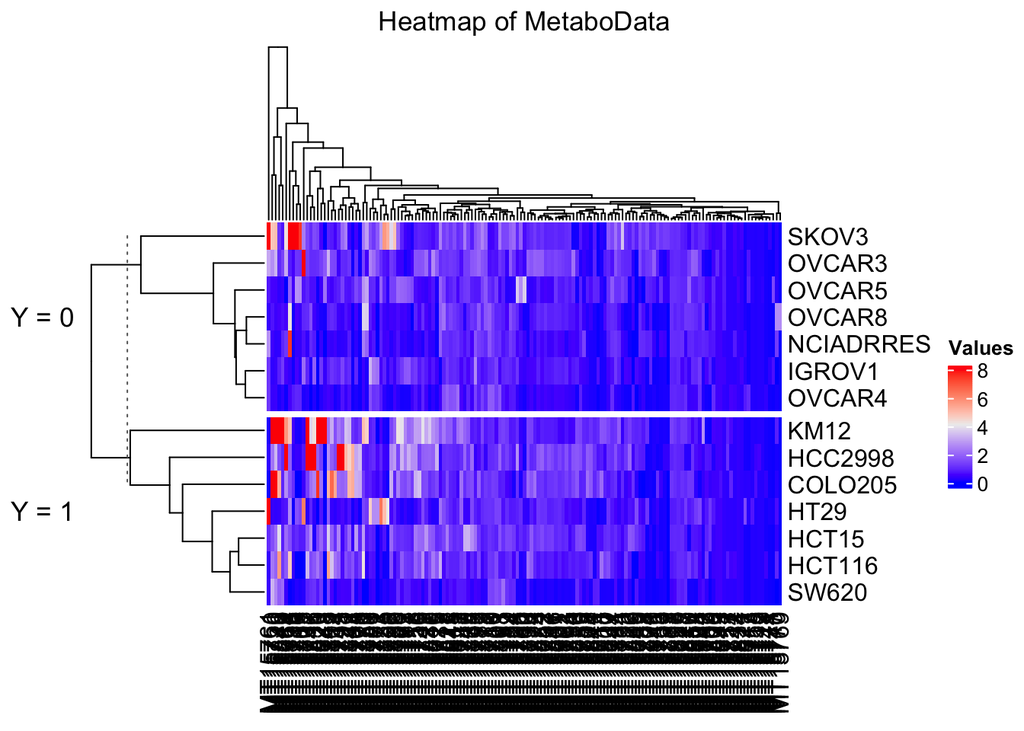

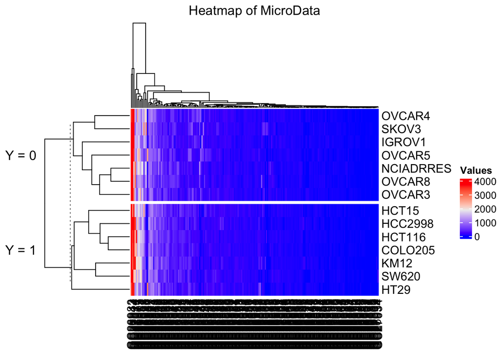

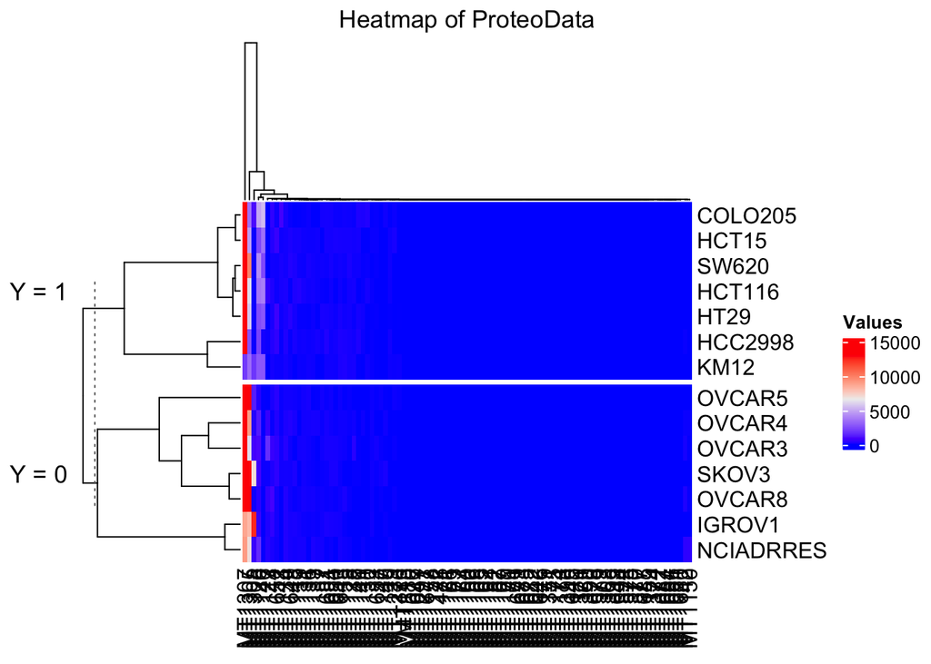

```r
# Heat map for each data block
lapply(X = 1:nbrBlocs,
       FUN = function(X){
         bloc <- BlockNames[X]
         heatmap_data(data = demo_3_Omics_not_scaled[[bloc]],
                      bloc_name = bloc,
                      factor = demo_3_Omics_not_scaled$Y[,1])})
```

And on the scaled data:

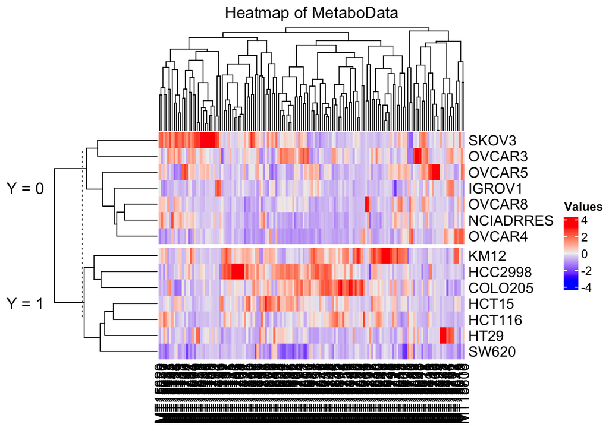

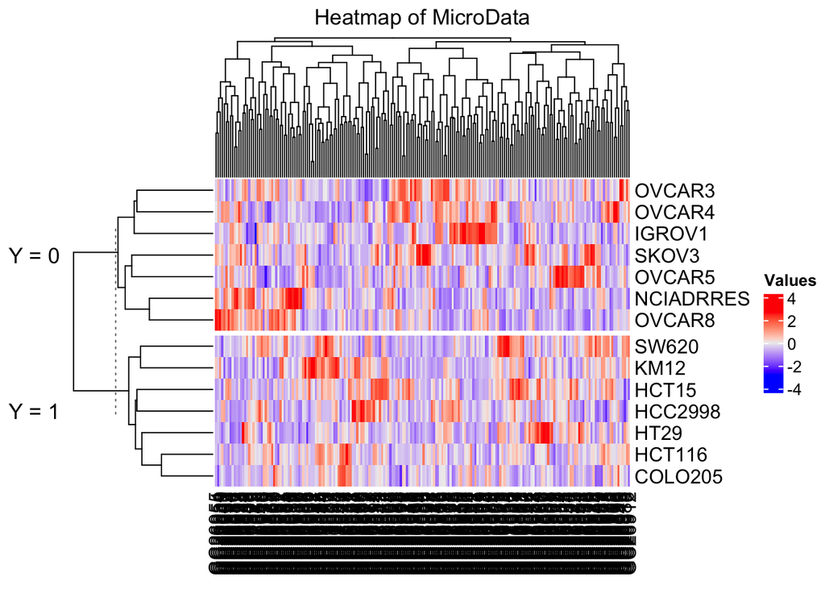

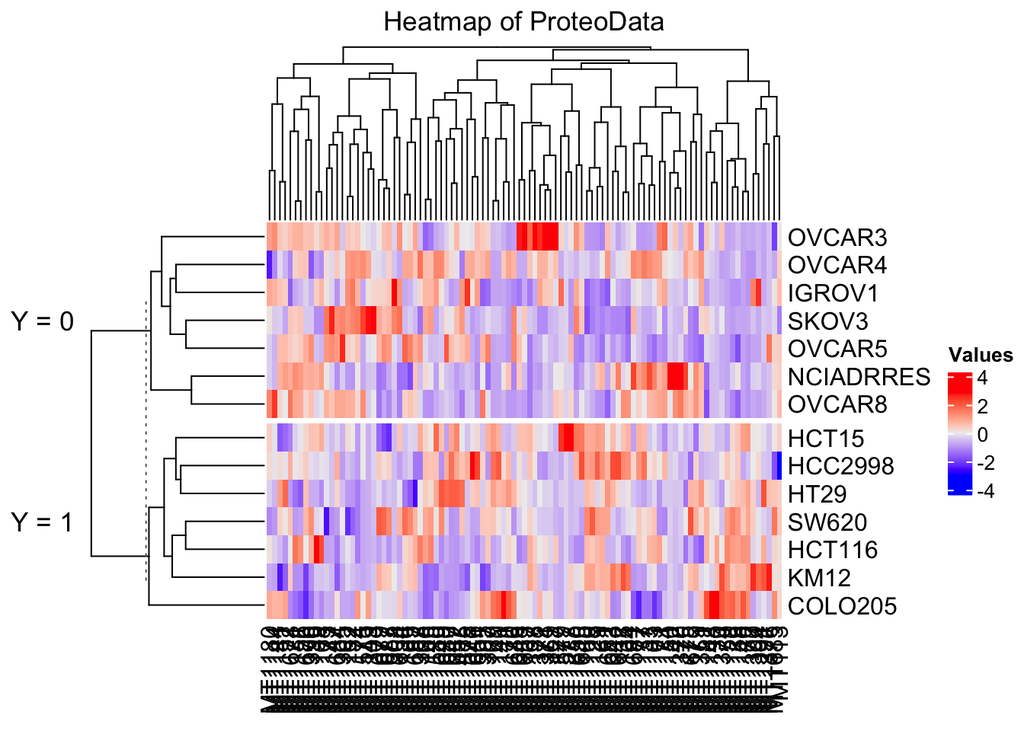

```r
# Heat map for each data block
lapply(X = 1:nbrBlocs,
       FUN = function(X){
         bloc <- BlockNames[X]
         heatmap_data(data = demo_3_Omics[[bloc]],
                      bloc_name = bloc,
                      factor = demo_3_Omics$Y[,1])})
```

By comparing these graphs, several observations can be made. To begin with, the unscaled data had a weak signal for the proteomics and transcriptomics blocks. The metabolomics block seemed to contain a relatively usable signal as it stood. These graphs therefore confirm that it was wise to perform this transformation prior to the analyses. And secondly, the profiles seem to differ according to the Y response variable.

In the same way, the user can visualize density distribution using a heat map (here on scaled data):

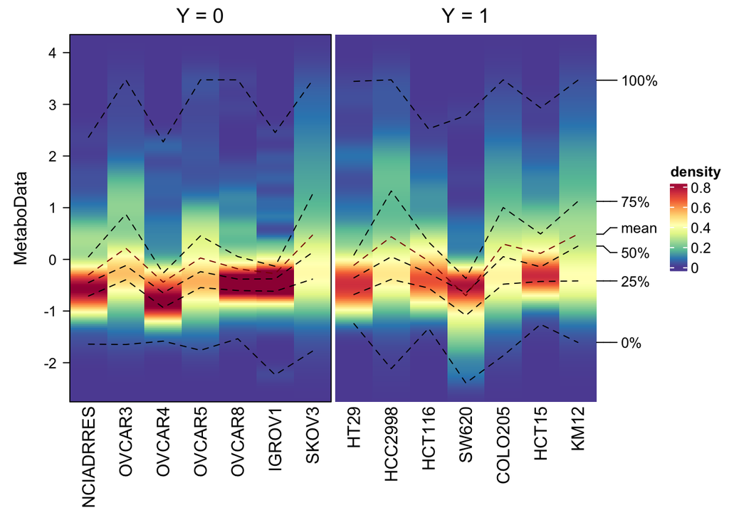

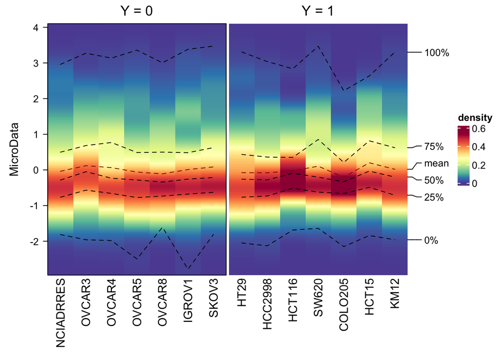

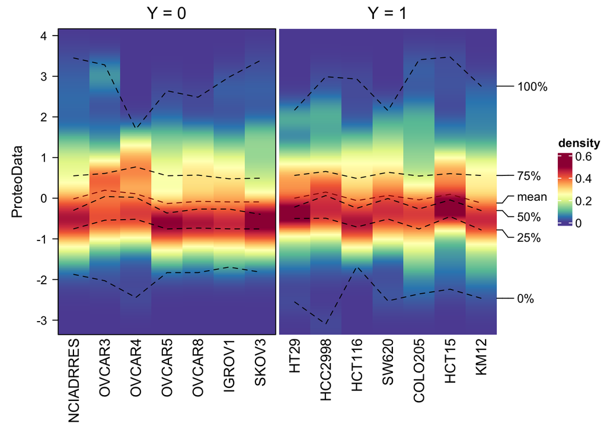

```r
# Heatmap with density for each data bloc
lapply(X = 1:nbrBlocs,
       FUN = function(X){
         bloc <- BlockNames[X]
         factor <- demo_3_Omics$Y[, 1]
         densityHeatmap(t(demo_3_Omics[[bloc]]),
                        ylab = bloc,
                        column_split  = factor,
                        column_title = "Y = %s")})
```

```r
# Remove unscaled data
rm(demo_3_Omics_not_scaled)
```

# 5 Consensus OPLS-DA model

A model with a predictor variable and an orthogonal latent variable was evaluated. For this, the following parameters were defined:

```r
# Number of predictive component(s)
LVsPred <- 1

# Maximum number of orthogonal components
LVsOrtho <- 3

# Number of cross-validation folds
CVfolds <- nrow(demo_3_Omics[[BlockNames[[1]]]])
CVfolds
```

```
## [1] 14
```

```r
copls.da <- ConsensusOPLS(data = demo_3_Omics[BlockNames],
                          Y = demo_3_Omics$Y,
                          maxPcomp = LVsPred,
                          maxOcomp  = LVsOrtho,
                          modelType = "da",
                          nperm = 1000,
                          cvType = "nfold",
                          nfold = 14,
                          nMC = 100,
                          cvFrac = 4/5,
                          kernelParams = list(type = "p",
                                              params = c(order = 1)),
                          mc.cores = 1)
```

The summary information of the model can be obtained as

```r
copls.da
```

```
## ***Optimal Consensus OPLS model***
##
## Mode:  da
##
## Number of predictive components:  1
##
## Number of orthogonal components:  1
##
## Block contribution:
##                  p_1       o_1
## MetaboData 0.2684595 0.4178126
## MicroData  0.3470002 0.3129129
## ProteoData 0.3845402 0.2692744
##
## Explained variance R2 in response: 0.995081
##
## Predictive ability (cross validation Q2):  0.7654607
```

The list of available attributes in the produced ConsensusOPLS object:

```r
summary(attributes(copls.da))
```

```
##                   Length Class  Mode
## modelType          1     -none- character
## response          14     -none- character
## nPcomp             1     -none- numeric
## nOcomp             1     -none- numeric
## blockContribution  6     -none- numeric
## scores            28     -none- numeric
## loadings           3     -none- list
## VIP                3     -none- list
## R2X                2     -none- numeric
## R2Y                2     -none- numeric
## Q2                 2     -none- numeric
## DQ2                2     -none- numeric
## permStats          3     -none- list
## model              5     -none- list
## cv                 0     -none- list
## class              1     -none- character
```

# 6 Display the main results

As indicated at the beginning of the file, the R package `ConsensusOPLS` calculates:

- the R-squared (R²) coefficient, gives a measure of how predictive the model is and how much variation is explained by the model. The lowest R-squared is 0 and means that the points are not explained by the regression whereas the highest R-squared is 1 and means that all the points are explained by the regression line.

```r
position <- copls.da@nOcomp

paste0('R2: ', round(copls.da@R2Y[paste0("po", position)], 4))
```

```
## [1] "R2: 0.9951"
```

Here, that means the model explain 99.51$\%$ of the variation in the Y response variable.

- The Stone-Geisser Q² coefficient, also known as the redundancy index in cross-validation, is used to evaluate the quality of each structural equation, and thus to assess, independently of each other, the predictive quality of each model construct (Tenenhaus et al. 2005). If the Q² is positive, the model has predictive validity, whereas if it is negative, the model has no (absence of) predictive validity. It is defined as `1 - (PRESS/ TSS)`, with `PRESS` is the prediction error sum of squares, and `TSS` is the total sum of squares of the response vector Y (Westerhuis et al. 2008). This coefficient can take values between -1 and 1, but a positive coefficient with a high value is expected for predictive validity.

```r
paste0('Q2: ', round(copls.da@Q2[paste0("po", position)], 4))
```

```
## [1] "Q2: 0.7655"
```

Here, this means that the model has a predictive validity.

- the discriminant Q² index (`DQ2`) to assess the model fit as it does not penalize class predictions beyond the class label value. The `DQ2` is defined as `1 - (PRESSD/ TSS)`, with PRESSD is the prediction error sum of squares, disregarded when the class prediction is beyond the class label (i.e. `>1` or `<0`, for two classes named 0 and 1), and `TSS` is the total sum of squares of the response vector Y. This value is a measure for class prediction ability (Westerhuis et al. 2008). As with Q², this coefficient can take values between -1 and 1, but a positive coefficient with a high value is expected to have predictive validity.

```r
paste0('DQ2: ', round(copls.da@DQ2[paste0("po", position)], 4))
```

```
## [1] "DQ2: 0.728"
```

Here, this means that the model can predict classes.

- the variable Importance in projection (VIP) for each block of data (Wold, Sjöström, and Eriksson 2001). Within each block, the relevance of the variables in explaining variation in the Y response was assessed using the VIP parameter, which reflects the importance of the variables in relation to both response and projection quality (Galindo-Prieto, Eriksson, and Trygg 2015).

Similarly, `individual loadings` represent the contribution of variables in the space defined by the predictive and orthogonal components. Their `sign` indicates the direction of the contribution (positive for correlated with response; negative for anti-correlated with response), and the value indicates the intensity of the contribution.

Using the `VIP* sign(loadings)` value (Mehl et al. 2024), the relevant features, i.e. those with higher `|VIP|` values, can be represented as follows:

```r
# Compute the VIP
VIP <- copls.da@VIP

# Multiply VIP * sign(loadings for predictive component)
VIP_plot <- lapply(X = 1:nbrBlocs,
                   FUN = function(X){
                     sign_loadings <- sign(copls.da@loadings[[X]][, "p_1"])
                     result <- VIP[[X]][, "p"]*sign_loadings
                     return(sort(result, decreasing = TRUE))})
names(VIP_plot) <- BlockNames
```

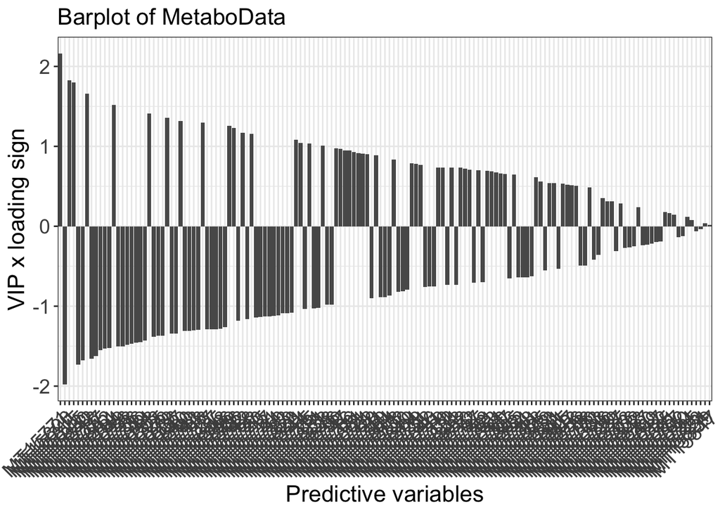

```r
# Metabo data
ggplot(data = data.frame(
  "variables" = factor(names(VIP_plot[[1]]),
                       levels=names(VIP_plot[[1]])[order(abs(VIP_plot[[1]]),
                                                         decreasing=T)]),
  "valeur" = VIP_plot[[1]]),
  aes(x = variables, y = valeur)) +
  geom_bar(stat = "identity") +
  labs(title = paste0("Barplot of ", names(VIP_plot)[1])) +
  xlab("Predictive variables") +
  ylab("VIP x loading sign") +
  theme_graphs +
  theme(axis.text.x = element_text(angle = 45, vjust = 1, hjust = 1))
```

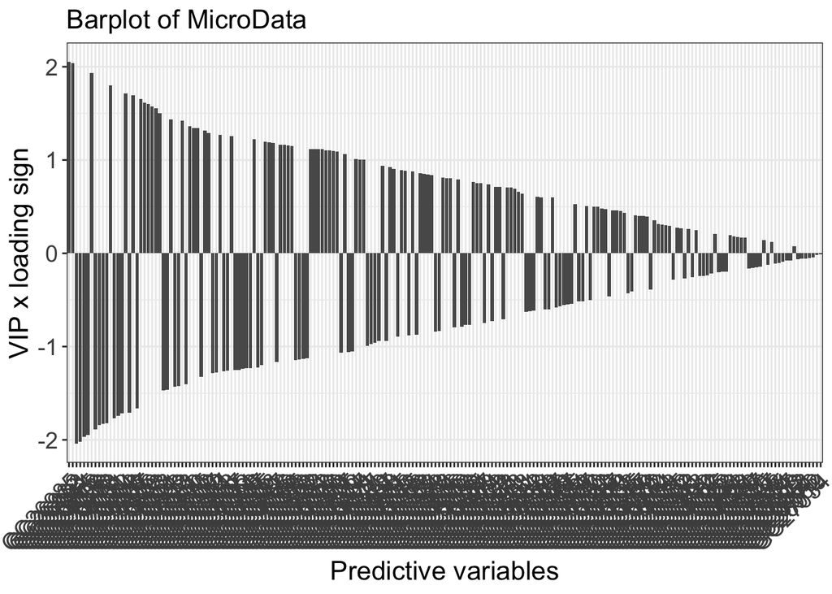

```r
# Microarray data
ggplot(data = data.frame(
  "variables" = factor(names(VIP_plot[[2]]),
                       levels=names(VIP_plot[[2]])[order(abs(VIP_plot[[2]]),
                                                         decreasing=T)]),
  "valeur" = VIP_plot[[2]]),
  aes(x = variables, y = valeur)) +
  geom_bar(stat = "identity") +
  labs(title = paste0("Barplot of ", names(VIP_plot)[2])) +
  xlab("Predictive variables") +
  ylab("VIP x loading sign") +
  theme_graphs +
  theme(axis.text.x = element_text(angle = 45, vjust = 1, hjust = 1))
```

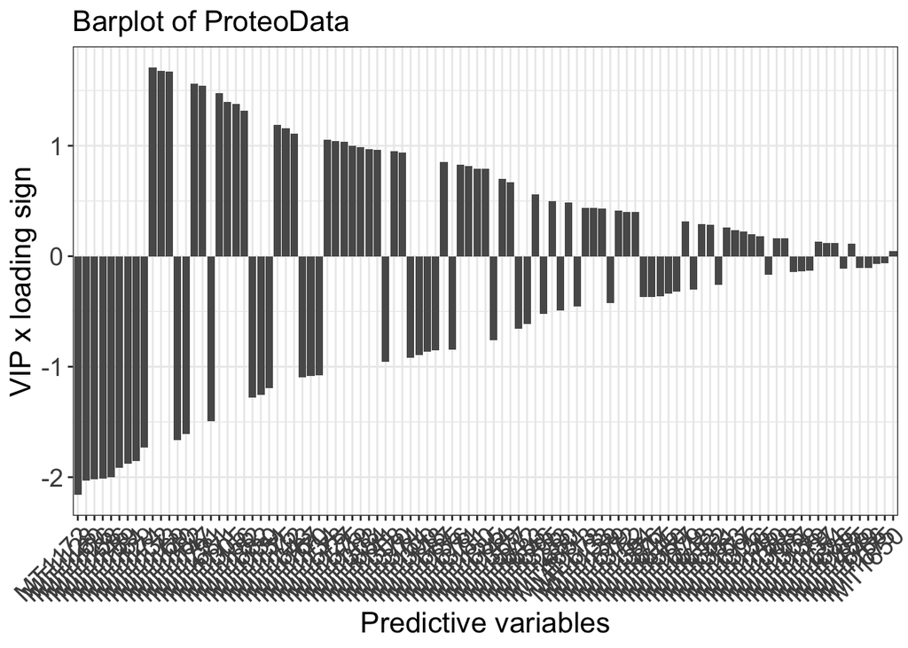

```r
# Proteo data
ggplot(data = data.frame(
  "variables" = factor(names(VIP_plot[[3]]),
                       levels=names(VIP_plot[[3]])[order(abs(VIP_plot[[3]]),
                                                         decreasing=T)]),
  "valeur" = VIP_plot[[3]]),
  aes(x = variables, y = valeur)) +
  geom_bar(stat = "identity") +
  labs(title = paste0("Barplot of ", names(VIP_plot)[3])) +
  xlab("Predictive variables") +
  ylab("VIP x loading sign") +
  theme_graphs +
  theme(axis.text.x = element_text(angle = 45, vjust = 1, hjust = 1))
```

One possibility might be to select only the 20 most important components (the first 10 and the last 10). The user is free to do this.

The advantage of using this representation, compared to individual loading, is that there is a usual selection threshold set at 1. In other words, variables with a VIP $\geq$ 1 are usually considered important.

# 7 Plot the main results

## 7.1 Consensus Score plot

The scores plot shows the representation of the samples in the two new components calculated by the optimal model. A horizontal separation (i.e. according to the predictive component) is expected.

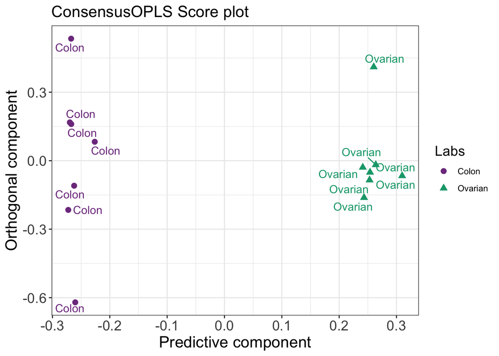

```r
ggplot(data = data.frame("p_1" = copls.da@scores[, "p_1"],
                         "o_1" = copls.da@scores[, "o_1"],
                         "Labs" = as.matrix(unlist(demo_3_Omics$ObsNames[, 1]))),
       aes(x = p_1, y = o_1, label = Labs,
           shape = Labs, colour = Labs)) +
  xlab("Predictive component") +
  ylab("Orthogonal component") +
  ggtitle("ConsensusOPLS Score plot")+
  geom_point(size = 2.5) +
  geom_text_repel(size = 4, show.legend = FALSE) +
  theme_graphs+
  scale_color_manual(values = c("#7F3C8D", "#11A579"))
```

Graph of scores obtained by the optimal ConsensusOPLS model for ovarian tissue (triangle) and colon tissue (circle) from NCI-60 data, for three data blocks (metabolomics, proteomics, and transcriptomics). Each cancer cell is represented by a unique symbol whose location is determined by the contributions of the predictive and orthogonal components of the ConsensusOPLS-DA model. A clear partition of the classes was obtained.

## 7.2 Block contributions to the predictive component

The contribution of the blocks represents the position of the samples in the new space of predictive and orthogonal components. In other words, intuitively, they represent the magnitude/importance of each block’s transformation in the new space.

Here, for the predictive component, this amounts to quantifying the information contribution of each block in the ConsensusOPLS model.

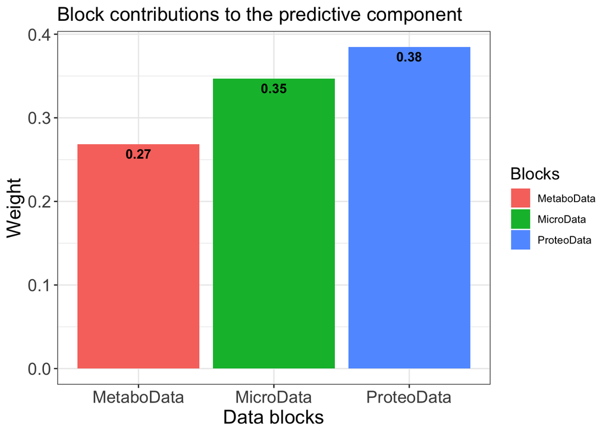

```r
ggplot(
  data = data.frame("Values" = copls.da@blockContribution[, "p_1"],
                    "Blocks" = as.factor(labels(demo_3_Omics[1:nbrBlocs]))),
  aes(x = Blocks, y = Values,
      fill = Blocks, labels = Values)) +
  geom_bar(stat = 'identity') +
  geom_text(aes(label = round(Values, 2), y = Values),
            vjust = 1.5, color = "black", fontface = "bold") +
  ggtitle("Block contributions to the predictive component")+
  xlab("Data blocks") +
  ylab("Weight") +
  theme_graphs +
  scale_color_manual(values = c("#1B9E77", "#D95F02", "#7570B3"))
```

The block contributions of the predictive latent variable indicated the specific importance of the proteomic block (38.5$\%$), the transcriptomic block (34.7$\%$) and the metabolomic block (26.8$\%$).

## 7.3 Block contributions to the first orthogonal component

For the orthogonal component, the block contribution quantifies the noise contribution of each block in the ConsensusOPLS model.

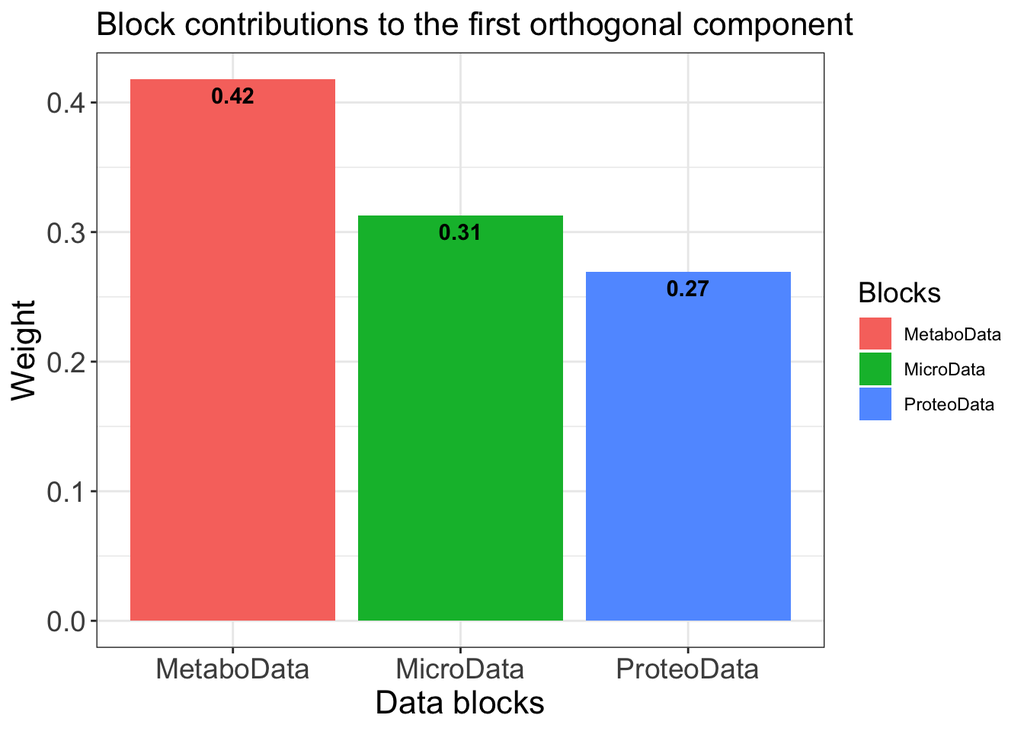

```r
ggplot(
  data =
    data.frame("Values" = copls.da@blockContribution[, "o_1"],
               "Blocks" = as.factor(labels(demo_3_Omics[1:nbrBlocs]))),
  aes(x = Blocks, y = Values,
      fill = Blocks, labels = Values)) +
  geom_bar(stat = 'identity') +
  geom_text(aes(label = round(Values, 2), y = Values),
            vjust = 1.5, color = "black", fontface = "bold") +
  ggtitle("Block contributions to the first orthogonal component") +
  xlab("Data blocks") +
  ylab("Weight") +
  theme_graphs +
  scale_color_manual(values = c("#1B9E77", "#D95F02", "#7570B3"))
```

The block contributions of first orthogonal component indicated the specific importance of the metabolomic block (41.8$\%$), the transcriptomic block (31.3$\%$) and the proteomic block (26.9$\%$).

## 7.4 Block contributions: the two previous plots into one

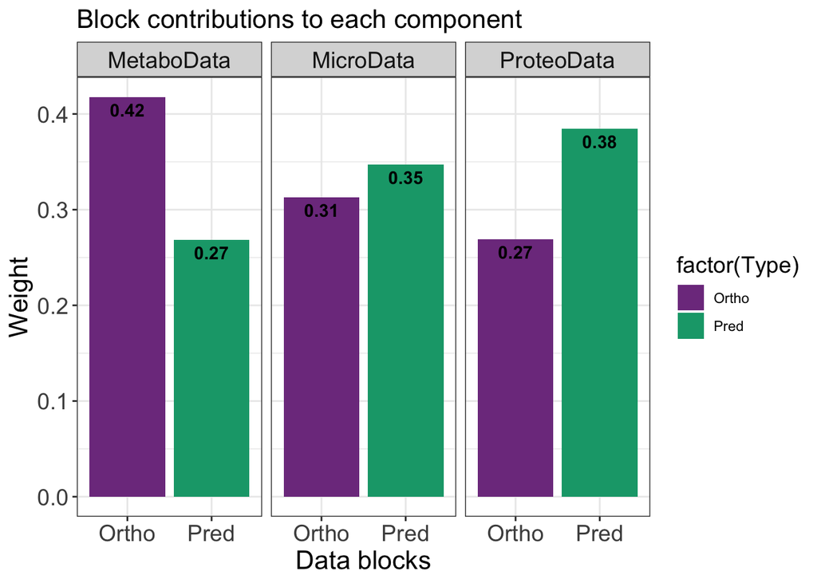

```r
data_two_plots <- data.frame("Values" = copls.da@blockContribution[, "p_1"],
                             "Type" = "Pred",
                             "Blocks" = labels(demo_3_Omics[1:nbrBlocs]))
data_two_plots <- data.frame("Values" = c(data_two_plots$Values,
                                          copls.da@blockContribution[, "o_1"]),
                             "Type" = c(data_two_plots$Type,
                                        rep("Ortho", times = length(copls.da@blockContribution[, "o_1"]))),
                             "Blocks" = c(data_two_plots$Blocks,
                                          labels(demo_3_Omics[1:nbrBlocs])))

ggplot(data = data_two_plots,
       aes(x = factor(Type),
           y = Values,
           fill = factor(Type))) +
  geom_bar(stat = 'identity') +
  ggtitle("Block contributions to each component")+
  geom_text(aes(label = round(Values, 2), y = Values),
            vjust = 1.5, color = "black", fontface = "bold") +
  xlab("Data blocks") +
  ylab("Weight") +
  facet_wrap(. ~ Blocks)+
  theme_graphs+
  scale_fill_discrete(name = "Component")+
  scale_fill_manual(values = c("#7F3C8D", "#11A579"))
```

In the same way, the previous graph can be represented as:

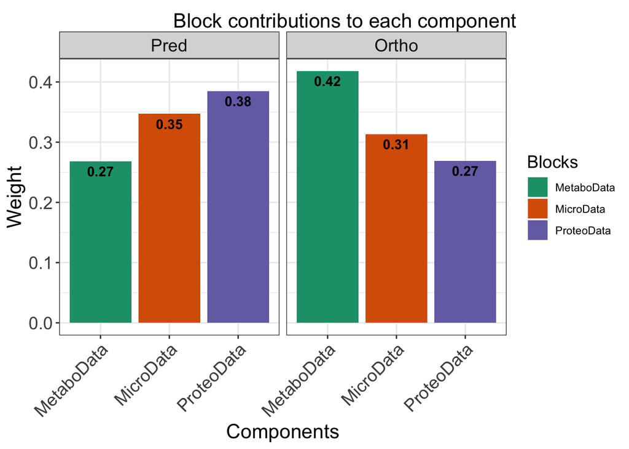

```r
ggplot(data = data_two_plots,
       aes(x = Blocks,
           y = Values,
           fill = Blocks)) +
  geom_bar(stat = 'identity') +
  geom_text(aes(label = round(Values, 2), y = Values),
            vjust = 1.5, color = "black", fontface = "bold") +
  ggtitle("Block contributions to each component") +
  xlab("Components") +
  ylab("Weight") +
  facet_wrap(. ~ factor(Type, levels = c("Pred", "Ortho"))) +
  theme_graphs +
  theme(axis.text.x = element_text(angle = 45, vjust = 1, hjust = 1),
        plot.title = element_text(hjust = 0.5,
                                  margin = margin(t = 5, r = 0, b = 0, l = 100))) +
  scale_fill_manual(values = c("#1B9E77", "#D95F02", "#7570B3"))
```

This synthetic figure is generally used in presentations.

## 7.5 Block contributions predictive vs. orthogonal

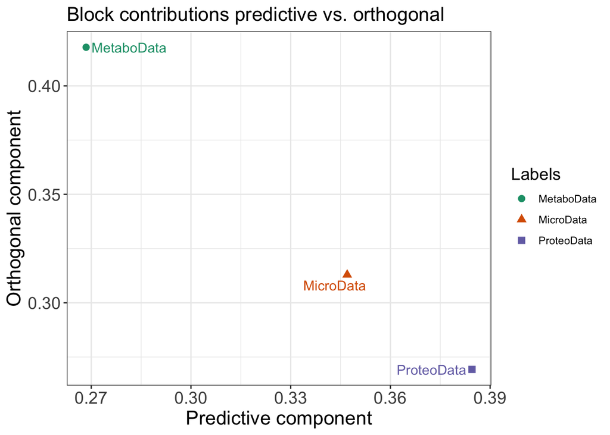

```r
ggplot(data = data.frame("Pred" = copls.da@blockContribution[, "p_1"],
                         "Ortho" = copls.da@blockContribution[, "o_1"],
                         "Labels" = labels(demo_3_Omics[1:nbrBlocs])),
       aes(x = Pred, y = Ortho, label = Labels,
           shape = Labels, colour = Labels)) +
  xlab("Predictive component") +
  ylab("Orthogonal component") +
  ggtitle("Block contributions predictive vs. orthogonal") +
  geom_point(size = 2.5) +
  geom_text_repel(size = 4, show.legend = FALSE) +
  theme_graphs +
  scale_color_manual(values = c("#1B9E77", "#D95F02", "#7570B3"))
```

## 7.6 Loading plots (one for each data set)

Individual loading of each block were calculated for the predictive latent variable of the optimal model, to detect metabolite, protein and transcript level differences between the two groups of tissues cell lines.

```r
loadings <- copls.da@loadings
data_loads <- sapply(X = 1:nbrBlocs,
                     FUN = function(X){
                       data.frame("Pred" =
                                    loadings[[X]][, grep(pattern = "p_",
                                                         x = colnames(loadings[[X]]),
                                                         fixed = TRUE)],
                                  "Ortho" =
                                    loadings[[X]][, grep(pattern = "o_",
                                                         x = colnames(loadings[[X]]),
                                                         fixed = TRUE)],
                                  "Labels" = labels(demo_3_Omics[1:nbrBlocs])[[X]])
                     })
data_loads <- as.data.frame(data_loads)
```

The loading plot shows the representation of variables in the two new components calculated by the optimal model.

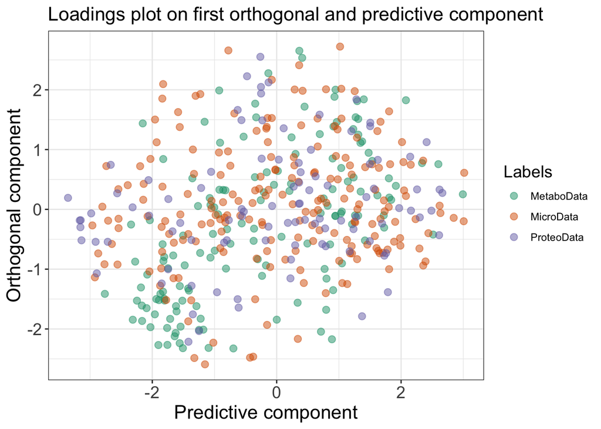

```r
ggplot() +
  geom_point(data = as.data.frame(data_loads$V1),
             aes(x = Pred, y = Ortho, colour = Labels),
             size = 2.5, alpha = 0.5) +
  geom_point(data = as.data.frame(data_loads$V2),
             aes(x = Pred, y = Ortho, colour = Labels),
             size = 2.5, alpha = 0.5) +
  geom_point(data = as.data.frame(data_loads$V3),
             aes(x = Pred, y = Ortho, colour = Labels),
             size = 2.5, alpha = 0.5) +
  xlab("Predictive component") +
  ylab("Orthogonal component") +
  ggtitle("Loadings plot on first orthogonal and predictive component")+
  theme_graphs+
  scale_color_manual(values = c("#1B9E77", "#D95F02", "#7570B3"))
```

The graph here represents the dispersion of variable contributions on orthogonal and predictive components, displaying intra- and inter-block variation. Intuitively, we would expect significant distinct variables to stand out horizontally (i.e. according to the predictive component). In omics data, due to the large amount of information, this is rarely the case: the explanatory importance is not clearly distinguishable, so we get an unstructured scatterplot (distributed in ellipsoidal form).

## 7.7 Loading and VIP of the optimal model

```r
loadings <- do.call(rbind.data.frame, copls.da@loadings)
loadings$block <- do.call(c, lapply(names(copls.da@loadings), function(x)
  rep(x, nrow(copls.da@loadings[[x]]))))
loadings$variable <- gsub(paste(paste0(names(copls.da@loadings), '.'),
                                collapse='|'), '',
                          rownames(loadings))

VIP <- do.call(rbind.data.frame, copls.da@VIP)
VIP$block <- do.call(c, lapply(names(copls.da@VIP), function(x)
  rep(x, nrow(copls.da@VIP[[x]]))))
VIP$variable <- gsub(paste(paste0(names(copls.da@VIP), '.'),
                           collapse='|'), '',
                     rownames(VIP))

loadings_VIP <- merge(x = loadings[, c("p_1", "variable")],
                      y = VIP[, c("p", "variable")],
                      by = "variable", all = TRUE)
colnames(loadings_VIP) <- c("variable", "loadings", "VIP")
loadings_VIP <- merge(x = loadings_VIP,
                      y = loadings[, c("block", "variable")],
                      by = "variable", all = TRUE)
loadings_VIP$label <- ifelse(loadings_VIP$VIP > 1, loadings_VIP$variable, NA)
```

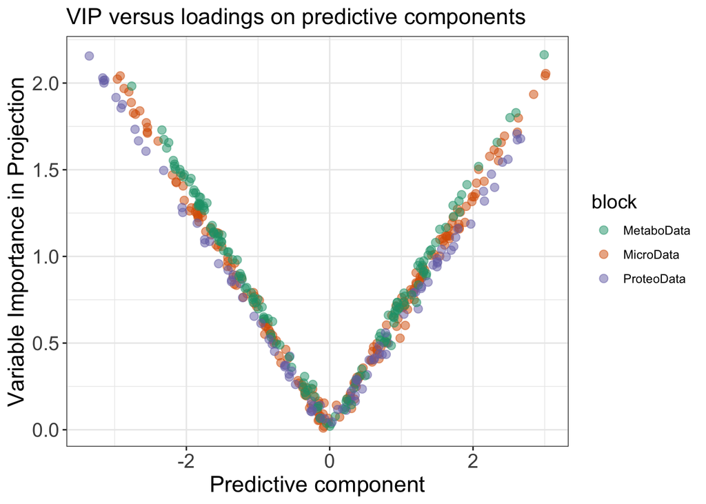

```r
ggplot(data = loadings_VIP,
       aes(x=loadings, y=VIP, col=block, label = label)) +
  geom_point(size = 2.5, alpha = 0.5) +
  xlab("Predictive component") +
  ylab("Variable Importance in Projection") +
  ggtitle("VIP versus loadings on predictive components")+
  theme_graphs+
  scale_color_manual(values = c("#1B9E77", "#D95F02", "#7570B3"))
```

Again, intuitively, VIPs are linearly dependent on individual loadings, which means that the scatterplot should have a V-shape: a positive slope for loadings correlated to the response variable and a negative one for loadings anti-correlated to the response variable. In practice, this is not always the case. In fact, this graph can be used to :

- detect outliers if the V shape is not respected ;
- assess the robustness of the model in a different way from the indicators presented above ;
- verify the expected linear dependence between VIPs and loadings
- select top features to contribute to the model.

# 8 Permutations

The permutations test (Szymańska et al. 2012) (for both the R² and Q²/ DQ² indicators) assesses the robustness of the model. The test hypothesis determines whether the model is statistically significant or has picked up noise in the data. For this, a permutation (random mixing) of the values of the response variable Y is performed, with the aim of destroying the structural relationship existing between X and Y. With each permutation, the ConsensusOPLS model is re-evaluated. In the end, for the optimal model to be robust, we need :

- the value of the optimal model must be within the high values of the permutations (the true value, represented by the vertical dotted line, must be on the right-hand side of the graph),
- the distribution of all permuted values to be relatively Gaussian (see density, shown in blue on the graph).

If these two criteria are met, then the model is robust and the results interpretive.

According to (Szymańska et al. 2012), authors have suggested that to estimate a permutation `P` value of 0.01, up to `10^4` permutations are required in genetic applications. In our case, permutation tests were done with `10^3` replicates to test model validity.

```r
PermRes <- copls.da@permStats
```

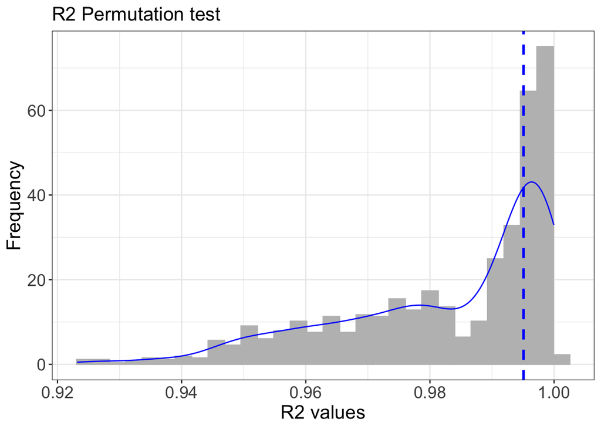

```r
ggplot(data = data.frame("R2Yperm" = PermRes$R2Y),
       aes(x = R2Yperm)) +
  geom_histogram(aes(y = after_stat(density)), bins = 30,
                 color="grey", fill="grey") +
  geom_density(color = "blue", linewidth = 0.5) +
  geom_vline(aes(xintercept=PermRes$R2Y[1]),
             color="blue", linetype="dashed", size=1) +
  xlab("R2 values") +
  ylab("Frequency") +
  ggtitle("R2 Permutation test")+
  theme_graphs
```

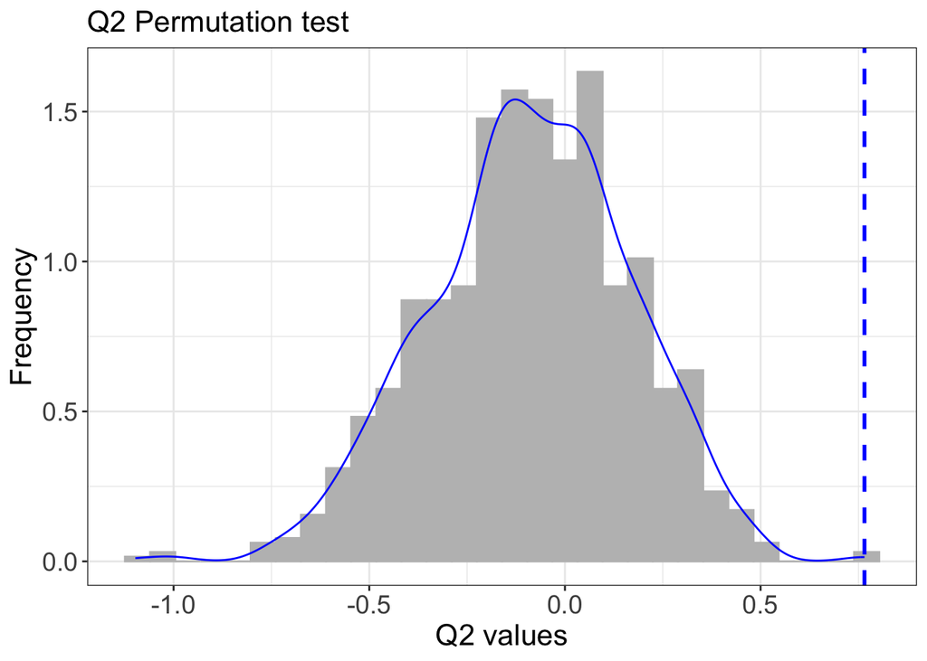

```r
ggplot(data = data.frame("Q2Yperm" = PermRes$Q2Y),
       aes(x = Q2Yperm)) +
  geom_histogram(aes(y = after_stat(density)), bins = 30,
                 color="grey", fill="grey") +
  geom_density(color = "blue", size = 0.5) +
  geom_vline(aes(xintercept=PermRes$Q2Y[1]),
             color="blue", linetype="dashed", size=1) +
  xlab("Q2 values") +
  ylab("Frequency") +
  ggtitle("Q2 Permutation test")+
  theme_graphs
```

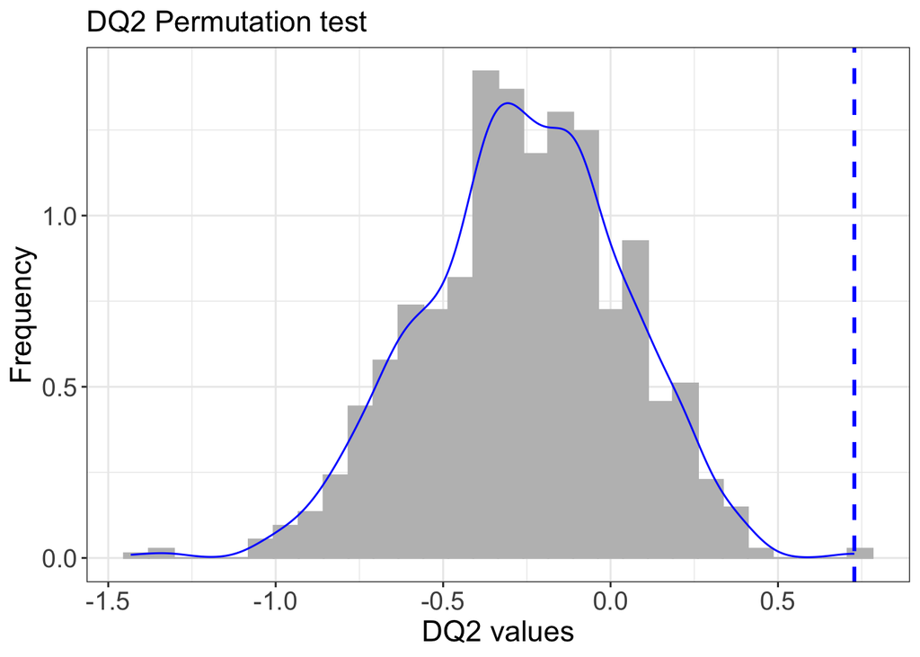

```r
ggplot(data = data.frame("DQ2Yperm" = PermRes$DQ2Y),
       aes(x = DQ2Yperm)) +
  geom_histogram(aes(y = after_stat(density)), bins = 30,
                 color="grey", fill="grey") +
  geom_density(color = "blue", size = 0.5) +
  geom_vline(aes(xintercept=PermRes$DQ2Y[1]),
             color="blue", linetype="dashed", size=1) +
  xlab("DQ2 values") +
  ylab("Frequency") +
  ggtitle("DQ2 Permutation test")+
  theme_graphs
```

We can then estimate the robustness of the built model with such plots.

# 9 Prediction

The model can then be used to predict the response of new data with the same structure as the input data. For instance, an attempt to repredict the response of `demo_3_Omics` can be done as follows:

```r
reprediction <- predict(copls.da, newdata = demo_3_Omics[BlockNames])
```

`Y` shows the estimated response from the model and `class` indicates the class determined by the highest estimated response, along with the confidence score measured by the margin between the highest estimated response and the second highest value, and also by the softmax probability.

```r
reprediction$Y
```

```
##                  Colon       Ovarian
## HT29       1.010230132 -0.0102301324
## HCC2998    1.000227805 -0.0002278046
## HCT116     0.931626379  0.0683736213
## SW620      1.009848738 -0.0098487376
## COLO205    1.019750222 -0.0197502217
## HCT15      1.014562172 -0.0145621723
## KM12       0.996538043  0.0034619570
## NCIADRRES  0.035633998  0.9643660020
## OVCAR3    -0.003387164  1.0033871644
## OVCAR4     0.017229468  0.9827705322
## OVCAR5     0.039830231  0.9601697688
## OVCAR8    -0.091129657  1.0911296573
## IGROV1     0.015656361  0.9843436391
## SKOV3      0.003383273  0.9966167266
```

```r
reprediction$class
```

|  | class | margin | softmax.Colon | softmax.Ovarian |
| --- | --- | --- | --- | --- |
| HT29 | Colon | 1.0204603 | 1.0000000 | 0.0e+00 |
| HCC2998 | Colon | 1.0004556 | 1.0000000 | 0.0e+00 |
| HCT116 | Colon | 0.8632528 | 0.9999968 | 3.2e-06 |
| SW620 | Colon | 1.0196975 | 1.0000000 | 0.0e+00 |
| COLO205 | Colon | 1.0395004 | 1.0000000 | 0.0e+00 |
| HCT15 | Colon | 1.0291243 | 1.0000000 | 0.0e+00 |
| KM12 | Colon | 0.9930761 | 1.0000000 | 0.0e+00 |
| NCIADRRES | Ovarian | 0.9287320 | 0.0000000 | 1.0e+00 |
| OVCAR3 | Ovarian | 1.0067743 | 0.0000000 | 1.0e+00 |
| OVCAR4 | Ovarian | 0.9655411 | 0.0000000 | 1.0e+00 |
| OVCAR5 | Ovarian | 0.9203395 | 0.0000000 | 1.0e+00 |
| OVCAR8 | Ovarian | 1.1822593 | 0.0000000 | 1.0e+00 |
| IGROV1 | Ovarian | 0.9686873 | 0.0000000 | 1.0e+00 |
| SKOV3 | Ovarian | 0.9932335 | 0.0000000 | 1.0e+00 |

# References

Boccard, Julien, and Serge Rudaz. 2014. “Harnessing the Complexity of Metabolomic Data with Chemometrics.” *Journal of Chemometrics* 28 (1): 1–9. https://doi.org/https://doi.org/10.1002/cem.2567.

Boccard, Julien, and Douglas N Rutledge. 2013. “A Consensus Orthogonal Partial Least Squares Discriminant Analysis (OPLS-DA) Strategy for Multiblock Omics Data Fusion.” *Analytica Chimica Acta* 769 (March): 30–39. https://doi.org/10.1016/j.aca.2013.01.022.

Galindo-Prieto, Beatriz, Lennart Eriksson, and Johan Trygg. 2015. “Variable Influence on Projection (VIP) for OPLS Models and Its Applicability in Multivariate Time Series Analysis.” *Chemometrics and Intelligent Laboratory Systems* 146: 297–304. https://doi.org/10.1016/j.chemolab.2015.05.001.

Lindgren, Fredrik, Paul Geladi, and Svante Wold. 1993. “The Kernel Algorithm for PLS.” *Journal of Chemometrics* 7 (1): 45–59. https://doi.org/10.1002/cem.1180070104.

Mehl, Florence, Ana Rodrı́guez Sánchez-Archidona, Ida Meitil, Mathias Gerl, Céline Cruciani-Guglielmacci, Leonore Wigger, Hervé Le Stunff, et al. 2024. “A Multiorgan Map of Metabolic, Signaling, and Inflammatory Pathways That Coordinately Control Fasting Glycemia in Mice.” *Iscience* 27 (11). https://doi.org/10.1016/j.isci.2024.111134.

Shoemaker, Robert H. 2006. “The NCI60 Human Tumour Cell Line Anticancer Drug Screen.” *Nature Reviews. Cancer* 6 (10): 813—823. https://doi.org/10.1038/nrc1951.

Szymańska, Ewa, Edoardo Saccenti, Age K Smilde, and Johan A Westerhuis. 2012. “Double-Check: Validation of Diagnostic Statistics for PLS-DA Models in Metabolomics Studies.” *Metabolomics* 8: 3–16. https://doi.org/10.1007/s11306-011-0330-3.

Tenenhaus, Michel, Vincenzo Esposito Vinzi, Yves-Marie Chatelin, and Carlo Lauro. 2005. “PLS Path Modeling.” *Computational Statistics & Data Analysis* 48 (1): 159–205. https://doi.org/10.1016/j.csda.2004.03.005.

Westerhuis, Johan, Ewoud Velzen, Huub Hoefsloot, and Age Smilde. 2008. “Discriminant q 2 (DQ 2) for Improved Discrimination in PLSDA Models.” *Metabolomics* 4 (December): 293–96. https://doi.org/10.1007/s11306-008-0126-2.

Wold, Svante, Michael Sjöström, and Lennart Eriksson. 2001. “PLS-Regression: A Basic Tool of Chemometrics.” *Chemometrics and Intelligent Laboratory Systems* 58 (2): 109–30. https://doi.org/10.1016/S0169-7439(01)00155-1.